# Critcal CSS experiment - Data analysis

```r
library(ggplot2)
library(reshape)
library(e1071)
library(effsize)
library(dunn.test)
library(plyr)
library(gridExtra)
library(stringr)
library(e1071)
library(effsize)
```

Let us first load all measures obtained from the experiment.

```r
# Get the measures (cpu load, memory usage, energy consumption and load time) for the specific browser (equal to folder name).
get_data <- function(browser_name) {
  subjects_path = paste("./data", browser_name, "data/nexus6p", sep="/")
  subjects <- list.dirs(subjects_path, full.names = FALSE, recursive = FALSE)
  data <- data.frame(
    name = character(),
    critical = logical(),
    energy_consumption = double(),
    time = integer(),
    memory_usage = integer(),
    cpu_usage = double(),
    stringsAsFactors = FALSE
  )

  for (subject in subjects) {
    # Obtain android measures (CPU usage)
    cpu_data <- data.frame(cpu_util = numeric())
    for (run_file in list.files(path = paste(subjects_path, subject, browser_name, "android", sep="/"), full.names = TRUE)[-1]) {
      android_results <- read.csv(run_file)
      cpu_data[nrow(cpu_data) + 1, ] <- c(mean(android_results$cpu))
    }

    # Obtain Trepn measures (time and memory usage)
    memory_data <- data.frame(mem_usage = numeric())
    time_data <- data.frame(time=numeric())
    for (run_file in list.files(path = paste(subjects_path, subject, browser_name, "trepn", sep="/"), full.names = TRUE)[-1]) {
      trepn_results <- read.csv(run_file)
      memory_data[nrow(memory_data) + 1, ] <- c(mean(trepn_results[, 2]))
      time_data[nrow(time_data) + 1, ] <- c(max(trepn_results[, 1]))
    }

    # Obtain Batterystats measures (energy consumption)
    energy_data <- data.frame(energy = numeric())
    for (run_file in list.files(path = paste(subjects_path, subject, browser_name, "batterystats", sep="/"), full.names = TRUE, pattern = "^Joule")) {
      batterystats_results <- read.csv(run_file)
      energy_data[nrow(energy_data) + 1, ] <- c(mean(batterystats_results[1, ]))
    }

    run_data <- data.frame(
      rep(strsplit(subject, "-")[[1]][2], nrow(energy_data)),
      rep(startsWith(subject, "subjects_critical"), nrow(energy_data)),
      energy_data,
      time_data,
      memory_data,
      cpu_data
    )
    names(run_data) <- names(data)
    data <- rbind(data, run_data)
  }

  return(data)
}

firefox_data <- get_data("firefox")
chrome_data <- get_data("chrome")
```

Next, let us define a function to plot two histograms of values for non-critical and critical categories, as well as their qq plots.

```r
plot_hist_qq <- function(data, column, metric_label, unit_label, browser_name) {
  # Plot histogram
  hist_plot <- ggplot(data, aes_string(x = column, fill = 'critical', color = 'critical')) + geom_histogram(position = 'identity', alpha = 0.5) + xlab(paste(metric_label, ' (', unit_label, ')', sep='')) + ylab('Frequency') + ggtitle(paste('Histogram of ', metric_label, ' (', browser_name, ')', sep=''))+ scale_color_manual(labels=c('Original', 'Critical'), values=c('red', 'blue')) + scale_fill_manual(labels=c('Original', 'Critical'), values=c('red', 'blue')) + theme_minimal() +
    theme(plot.title = element_text(hjust = 0.5),
          axis.text.y   = element_text(size=14),
          axis.text.x   = element_text(size=14),
          axis.title.y  = element_text(size=14),
          axis.title.x  = element_text(size=14),
          panel.background = element_blank(),
          legend.position = c(0.9, 0.9),
          legend.title=element_blank(),
          axis.line = element_line(colour = "black"))

  # Plot qq
  qq_plot <- ggplot(data, aes_string(sample = column, fill = 'critical', color = 'critical')) + stat_qq(alpha = 0.5) +  stat_qq_line() + xlab('Theoretical Quantile') + ylab('Actual Quantile') + ggtitle(paste('Q-Q Plot of ', metric_label, ' (', browser_name, ')', sep='')) + scale_color_manual(labels=c('Original', 'Critical'), values=c('red', 'blue')) + scale_fill_manual(labels=c('Original', 'Critical'), values=c('red', 'blue')) + theme_minimal() +
    theme(plot.title = element_text(hjust = 0.5),
          axis.text.y   = element_text(size=14),
          axis.text.x   = element_text(size=14),
          axis.title.y  = element_text(size=14),
          axis.title.x  = element_text(size=14),
          panel.background = element_blank(),
          legend.position = c(0.1, 0.9),
          legend.title=element_blank(),
          axis.line = element_line(colour = "black"))

  show(hist_plot)
  show(qq_plot)
}
```

## RQ1

To get an impression of the distribution of the data, we first plot the histogram and qq plot of the energy consumption.

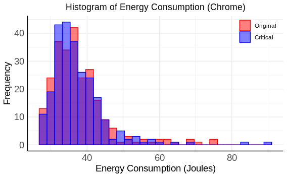

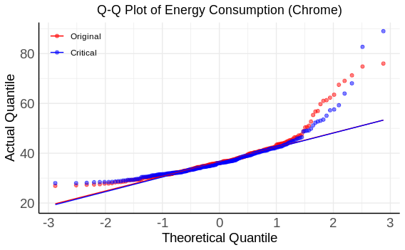

```r
plot_hist_qq(chrome_data, 'energy_consumption', "Energy Consumption", "Joules", 'Chrome')
```

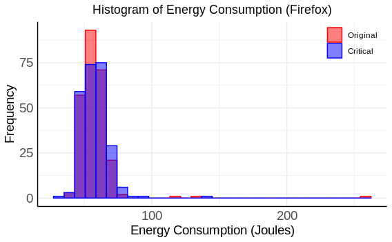

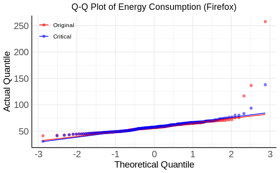

```r
plot_hist_qq(firefox_data, 'energy_consumption', "Energy Consumption", "Joules", 'Firefox')
```

In the above plots we observe some outliers, which we will *not* remove, to prevent potential bias. The actual quantiles seem to diverge from the theoretical quantiles, especially for Chrome, so we do not think these measures follow a normal distribution. To confirm, let us compute the skewness and perform a shapiro-wilk test.

```r
skewness_and_shapiro <- function(data, column) {
  print(paste('Skewness critical:', skewness(data[data$critical == TRUE, ][[column]])))
  print(paste('Skewness original:', skewness(data[data$critical == FALSE, ][[column]])))

  show(shapiro.test(data[data$critical == TRUE, ][[column]]))
  show(shapiro.test(data[data$critical == FALSE, ][[column]]))
}
```

```r
skewness_and_shapiro(chrome_data, 'energy_consumption')
```

```
[1] "Skewness critical: 2.74484270221612"
[1] "Skewness original: 2.04905754446189"

    Shapiro-Wilk normality test

data:  data[data$critical == TRUE, ][[column]]
W = 0.7838, p-value < 2.2e-16


    Shapiro-Wilk normality test

data:  data[data$critical == FALSE, ][[column]]
W = 0.82145, p-value = 2.956e-16
```

```r
skewness_and_shapiro(firefox_data, 'energy_consumption')
```

```
[1] "Skewness critical: 2.31677413396289"
[1] "Skewness original: 8.54367991659208"

    Shapiro-Wilk normality test

data:  data[data$critical == TRUE, ][[column]]
W = 0.86421, p-value = 4.521e-14


    Shapiro-Wilk normality test

data:  data[data$critical == FALSE, ][[column]]
W = 0.45222, p-value < 2.2e-16
```

For both chrome and firefox and both the original and critical versions of the web apps, a positive skewness is observed. Also, all shapiro-wilk test results yield a p-value < 0.05, meaning that we can reject H0 that these measures originate from a normal distribution.

To compensate for the skewness, let us consider transforming the data using log, square root and reciprocal transformations. All are suitable for positively skewed data.

```r
transform_and_test <- function(data, column, metric_label, unit_label, browser_name) {
  critical = data$critical

  print('SQRT')
  sqrt_transformed <- sqrt(data[[column]])
  plot_hist_qq(data.frame(critical, sqrt_transformed), 'sqrt_transformed', paste('SQRT-Transformed', metric_label), unit_label, browser_name)
  skewness_and_shapiro(data.frame(critical, sqrt_transformed), 'sqrt_transformed')

  print('LOG')
  log_transformed <- log10(data[[column]])
  plot_hist_qq(data.frame(critical, log_transformed), 'log_transformed', paste('LOG-Transformed', metric_label), unit_label, browser_name)
  skewness_and_shapiro(data.frame(critical, log_transformed), 'log_transformed')

  print('INV')
  inv_transformed <- 1 / data[[column]]
  plot_hist_qq(data.frame(critical, inv_transformed), 'inv_transformed', paste('INV-Transformed', metric_label), unit_label, browser_name)
  skewness_and_shapiro(data.frame(critical, inv_transformed), 'inv_transformed')
}
```

First, for chrome:

```
[1] "SQRT"
[1] "Skewness critical: 2.02962887943881"
[1] "Skewness original: 1.61487958201305"

    Shapiro-Wilk normality test

data:  data[data$critical == TRUE, ][[column]]
W = 0.85412, p-value = 1.259e-14


    Shapiro-Wilk normality test

data:  data[data$critical == FALSE, ][[column]]
W = 0.87632, p-value = 2.297e-13

[1] "LOG"
[1] "Skewness critical: 1.45699895180894"
[1] "Skewness original: 1.21254005222096"

    Shapiro-Wilk normality test

data:  data[data$critical == TRUE, ][[column]]
W = 0.90867, p-value = 3.261e-11


    Shapiro-Wilk normality test

data:  data[data$critical == FALSE, ][[column]]
W = 0.92129, p-value = 3.097e-10

[1] "INV"
[1] "Skewness critical: -0.640766356664557"
[1] "Skewness original: -0.519580157722328"

    Shapiro-Wilk normality test

data:  data[data$critical == TRUE, ][[column]]
W = 0.97336, p-value = 0.0001236


    Shapiro-Wilk normality test

data:  data[data$critical == FALSE, ][[column]]
W = 0.97778, p-value = 0.0005912
```

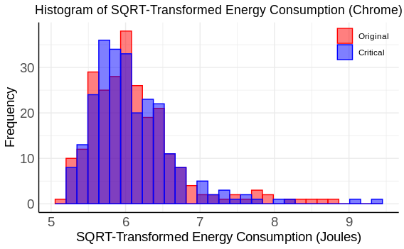

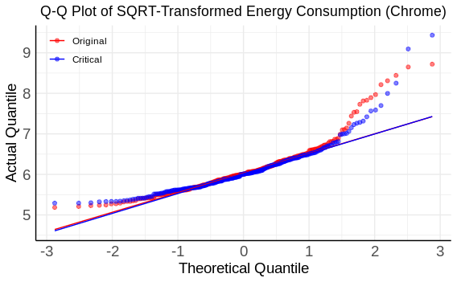

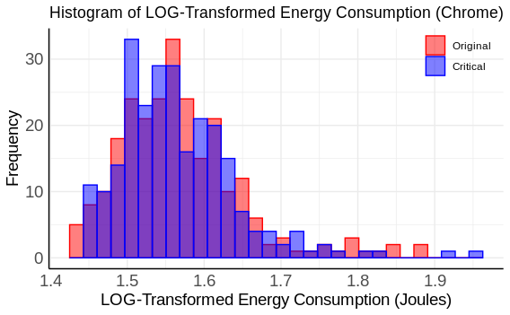

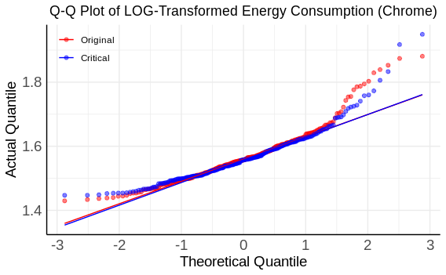

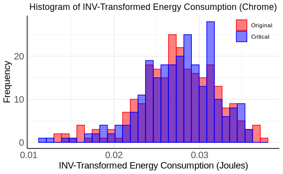

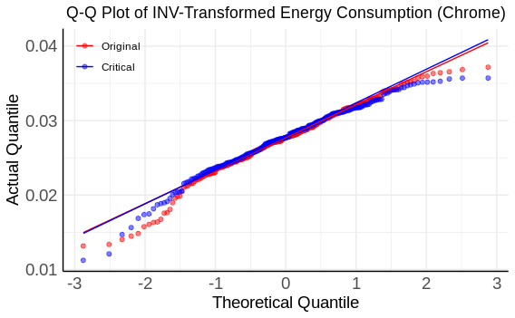

```r
transform_and_test(chrome_data, 'energy_consumption', "Energy Consumption", "Joules", 'Chrome')
```

Then firefox:

```
[1] "SQRT"
[1] "Skewness critical: 1.2792110740289"
[1] "Skewness original: 5.53692309035909"

    Shapiro-Wilk normality test

data:  data[data$critical == TRUE, ][[column]]
W = 0.92429, p-value = 5.478e-10


    Shapiro-Wilk normality test

data:  data[data$critical == FALSE, ][[column]]
W = 0.63618, p-value < 2.2e-16

[1] "LOG"
[1] "Skewness critical: 0.531022115847306"
[1] "Skewness original: 3.10297593547318"

    Shapiro-Wilk normality test

data:  data[data$critical == TRUE, ][[column]]
W = 0.95769, p-value = 1.062e-06


    Shapiro-Wilk normality test

data:  data[data$critical == FALSE, ][[column]]
W = 0.79295, p-value < 2.2e-16

[1] "INV"
[1] "Skewness critical: 0.575161458188057"
[1] "Skewness original: -0.609445072774475"

    Shapiro-Wilk normality test

data:  data[data$critical == TRUE, ][[column]]
W = 0.96077, p-value = 2.492e-06


    Shapiro-Wilk normality test

data:  data[data$critical == FALSE, ][[column]]
W = 0.94814, p-value = 9.208e-08
```

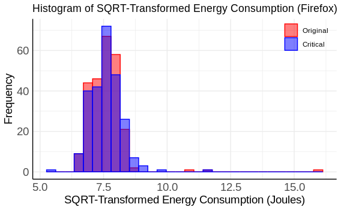

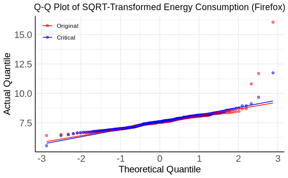

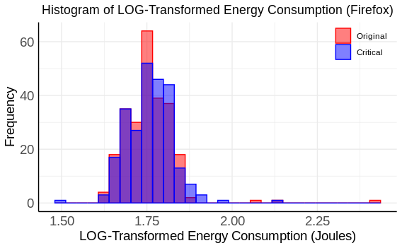

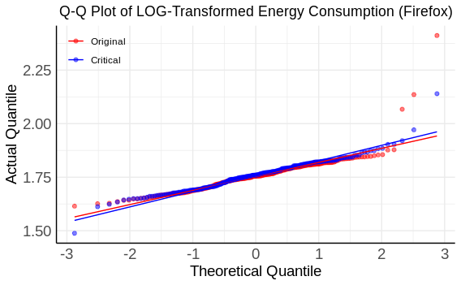

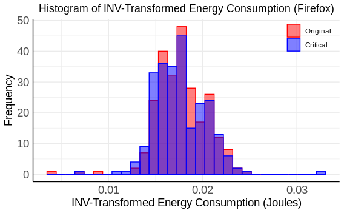

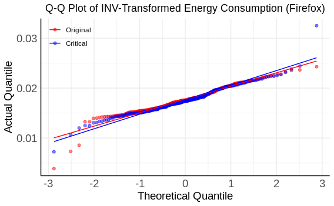

```r
transform_and_test(firefox_data, 'energy_consumption', "Energy Consumption", "Joules", 'Firefox')
```

As it turns out, none of the sets of measures seem to follow a normal distribution. We therefore perform only non-parametric tests. Let us consider the Wilcoxon non-parametric rank-based test.

```r
wilcox.test(chrome_data[chrome_data$critical == TRUE,]$energy_consumption, chrome_data[chrome_data$critical == FALSE,]$energy_consumption)
```

```
    Wilcoxon rank sum test with continuity correction

data:  chrome_data[chrome_data$critical == TRUE, ]$energy_consumption and chrome_data[chrome_data$critical == FALSE, ]$energy_consumption
W = 30730, p-value = 0.7478
alternative hypothesis: true location shift is not equal to 0
```

```r
wilcox.test(firefox_data[firefox_data$critical == TRUE,]$energy_consumption, firefox_data[firefox_data$critical == FALSE,]$energy_consumption)
```

```
    Wilcoxon rank sum test with continuity correction

data:  firefox_data[firefox_data$critical == TRUE, ]$energy_consumption and firefox_data[firefox_data$critical == FALSE, ]$energy_consumption
W = 32795, p-value = 0.339
alternative hypothesis: true location shift is not equal to 0
```

For both chrome and firefox the Wilcoxon test yields a p-value > 0.05, meaning that we cannot reject H0 that the difference between pairs follows a symmetric distribution around zero. Hence, we are not able to claim that web apps with or without application of the Critical CSS Technique consume different amounts of energy on our mobile device.

## RQ2

### Time

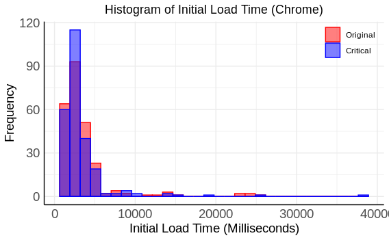

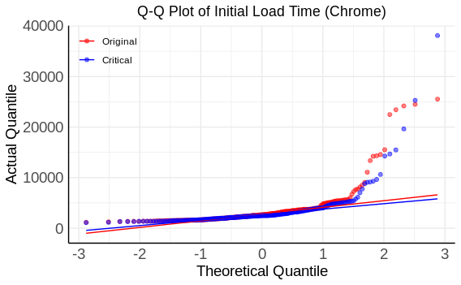

```r
plot_hist_qq(chrome_data, 'time', "Initial Load Time", "Milliseconds", 'Chrome')
```

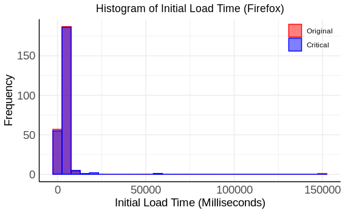

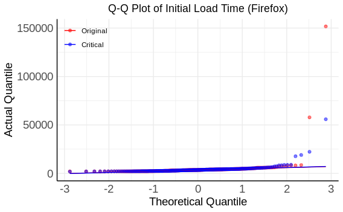

```r
plot_hist_qq(firefox_data, 'time', "Initial Load Time", "Milliseconds", 'Firefox')
```

In the above plots we observe some outliers, which we will *not* remove, to prevent potential bias. The actual quantiles seem to diverge from the theoretical quantiles, especially for Chrome, so we do not think these measures follow a normal distribution. To confirm, let us compute the skewness and perform a shapiro-wilk test.

```r
skewness_and_shapiro(chrome_data, 'time')
```

```
[1] "Skewness critical: 6.1062383826762"
[1] "Skewness original: 4.09652431941891"

    Shapiro-Wilk normality test

data:  data[data$critical == TRUE, ][[column]]
W = 0.44096, p-value < 2.2e-16


    Shapiro-Wilk normality test

data:  data[data$critical == FALSE, ][[column]]
W = 0.51081, p-value < 2.2e-16
```

```r
skewness_and_shapiro(firefox_data, 'time')
```

```
[1] "Skewness critical: 9.87763800830985"
[1] "Skewness original: 13.2292422184378"

    Shapiro-Wilk normality test

data:  data[data$critical == TRUE, ][[column]]
W = 0.31351, p-value < 2.2e-16


    Shapiro-Wilk normality test

data:  data[data$critical == FALSE, ][[column]]
W = 0.12131, p-value < 2.2e-16
```

For both chrome and firefox and both the original and critical versions of the web apps, a positive skewness is observed. Also, all shapiro-wilk test results yield a p-value < 0.05, meaning that we can reject H0 that these measures originate from a normal distribution.

To compensate for the skewness, let us consider transforming the data using log, square root and reciprocal transformations. All are suitable for positively skewed data.

First, for chrome:

```
[1] "SQRT"
[1] "Skewness critical: 3.46047672948992"
[1] "Skewness original: 2.76494294325588"

    Shapiro-Wilk normality test

data:  data[data$critical == TRUE, ][[column]]
W = 0.68757, p-value < 2.2e-16


    Shapiro-Wilk normality test

data:  data[data$critical == FALSE, ][[column]]
W = 0.7126, p-value < 2.2e-16

[1] "LOG"
[1] "Skewness critical: 1.59655196316126"
[1] "Skewness original: 1.44177718676659"

    Shapiro-Wilk normality test

data:  data[data$critical == TRUE, ][[column]]
W = 0.88892, p-value = 1.407e-12


    Shapiro-Wilk normality test

data:  data[data$critical == FALSE, ][[column]]
W = 0.8894, p-value = 1.51e-12

[1] "INV"
[1] "Skewness critical: 0.222235170903281"
[1] "Skewness original: 0.177847716064385"

    Shapiro-Wilk normality test

data:  data[data$critical == TRUE, ][[column]]
W = 0.99001, p-value = 0.08329


    Shapiro-Wilk normality test

data:  data[data$critical == FALSE, ][[column]]
W = 0.98481, p-value = 0.009175
```

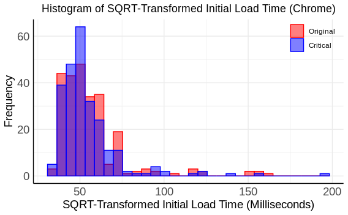

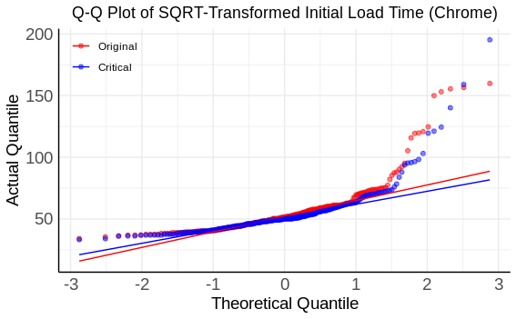

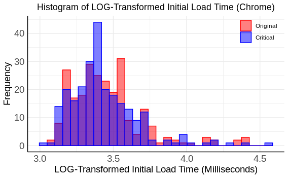

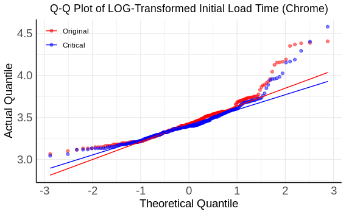

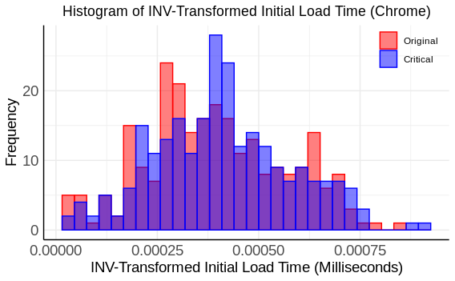

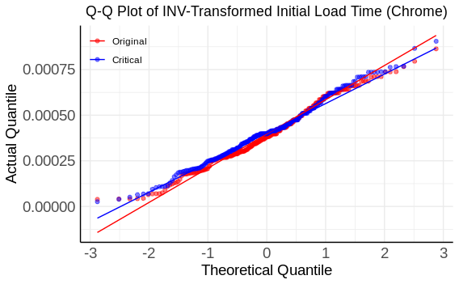

```r
transform_and_test(chrome_data, 'time', "Initial Load Time", "Milliseconds", 'Chrome')
```

Then firefox:

```
[1] "SQRT"
[1] "Skewness critical: 5.35572809366215"
[1] "Skewness original: 9.62321756736953"

    Shapiro-Wilk normality test

data:  data[data$critical == TRUE, ][[column]]
W = 0.60526, p-value < 2.2e-16


    Shapiro-Wilk normality test

data:  data[data$critical == FALSE, ][[column]]
W = 0.34582, p-value < 2.2e-16

[1] "LOG"
[1] "Skewness critical: 2.05645860848592"
[1] "Skewness original: 3.5240450630226"

    Shapiro-Wilk normality test

data:  data[data$critical == TRUE, ][[column]]
W = 0.86012, p-value = 2.673e-14


    Shapiro-Wilk normality test

data:  data[data$critical == FALSE, ][[column]]
W = 0.75736, p-value < 2.2e-16

[1] "INV"
[1] "Skewness critical: 0.153774455354763"
[1] "Skewness original: 0.210650963094012"

    Shapiro-Wilk normality test

data:  data[data$critical == TRUE, ][[column]]
W = 0.98041, p-value = 0.001593


    Shapiro-Wilk normality test

data:  data[data$critical == FALSE, ][[column]]
W = 0.96366, p-value = 5.748e-06
```

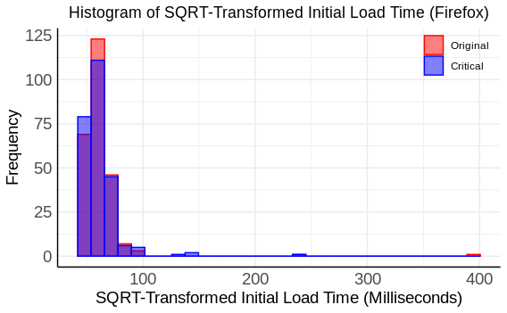

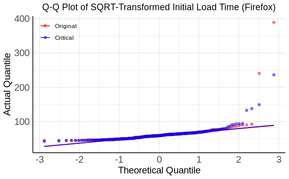

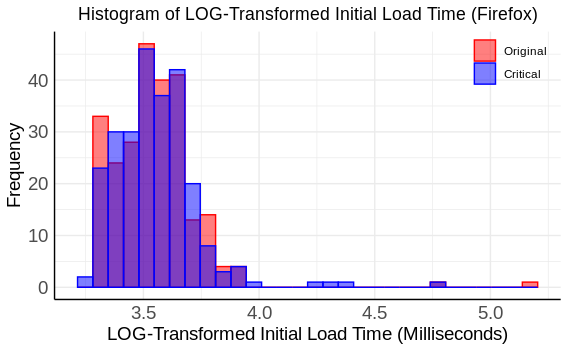

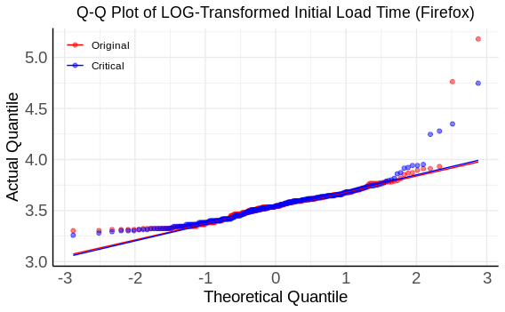

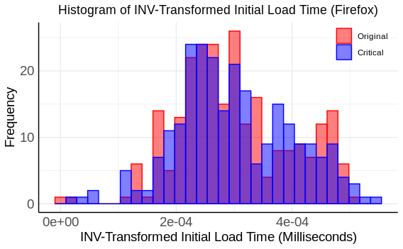

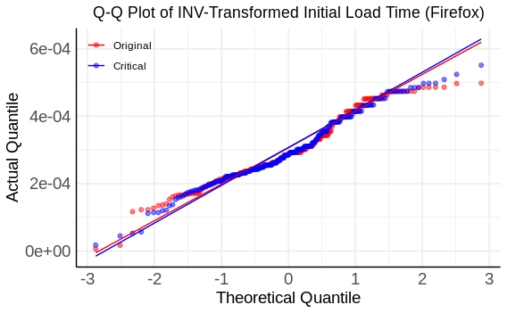

```r
transform_and_test(firefox_data, 'time', "Initial Load Time", "Milliseconds", 'Firefox')
```

```r
wilcox.test(chrome_data[chrome_data$critical == TRUE,]$time, chrome_data[chrome_data$critical == FALSE,]$time)
```

```
    Wilcoxon rank sum test with continuity correction

data:  chrome_data[chrome_data$critical == TRUE, ]$time and chrome_data[chrome_data$critical == FALSE, ]$time
W = 29326, p-value = 0.2339
alternative hypothesis: true location shift is not equal to 0
```

```r
wilcox.test(firefox_data[firefox_data$critical == TRUE,]$time, firefox_data[firefox_data$critical == FALSE,]$time)
```

```
    Wilcoxon rank sum test with continuity correction

data:  firefox_data[firefox_data$critical == TRUE, ]$time and firefox_data[firefox_data$critical == FALSE, ]$time
W = 31329, p-value = 0.9612
alternative hypothesis: true location shift is not equal to 0
```

For both chrome and firefox the Wilcoxon test yields a p-value > 0.05, meaning that we cannot reject H0 that the difference between pairs follows a symmetric distribution around zero. Hence, we are not able to claim that web apps with or without application of the Critical CSS Technique differ in their initial load time on our mobile device.